# Projet régression non paramétrique

#Question 1 Nous utilisons la fonction *bkde* du package *KernSmooth* pour construire un estimateur non paramétrique du design *g*. Nous représentons graphiquement cette estimateur pour 4 valeurs différents de *h*. Le choix de *h* est déterminant. Nous remarquons en effet que : - plus h est petit, plus l’estimateur sera oscillant (variance importante) mais avec un faible biais, - plus h est grand, plus l’estimateur sera régulier mais avec un biais important.

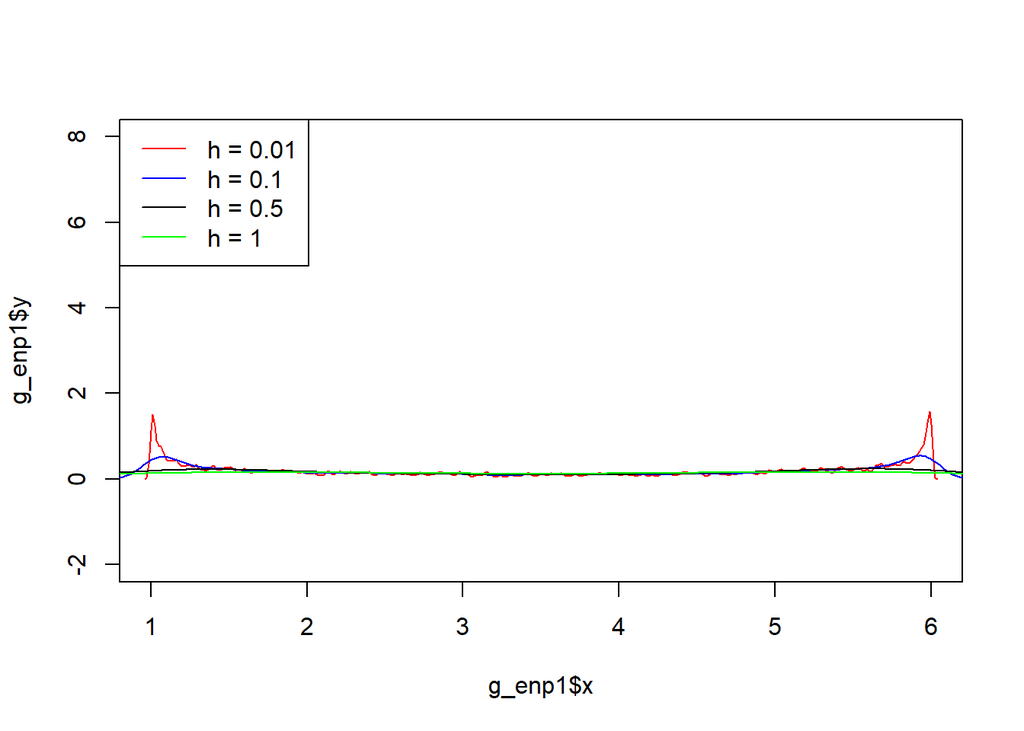

```r
g_enp1 = bkde(data$X, kernel = "normal",canonical = F, bandwidth = 0.01, truncate = F)
g_enp2 = bkde(data$X, kernel = "normal", canonical = F, bandwidth = 0.1, truncate = F)
g_enp3 = bkde(data$X, kernel = "normal",canonical = F, bandwidth = 0.5, truncate = F)
g_enp4 = bkde(data$X, kernel = "normal",canonical = F, bandwidth = 1, truncate = F)
plot(g_enp1$x, g_enp1$y, type = "l", col = "red", xlim = c(1,6),ylim=c(-2,8))
lines(g_enp2$x, g_enp2$y, type = "l", col = "blue")
lines(g_enp3$x, g_enp3$y, type = "l", col = "black")
lines(g_enp4$x, g_enp4$y, type = "l", col = "green")
legend("topleft", c("h = 0.01", "h = 0.1", "h = 0.5", "h = 1"), col = c("red", "blue", "black", "green"), lty = 1)
```

##Question 2 Nous calculons la fenêtre *optimale* en utilisant la fonction *h.select* du package *sm*

```r
hn = h.select(data$X, method = "cv")
print(paste0("hn = ",hn))
```

```
## [1] "hn = 0.26215847425182"
```

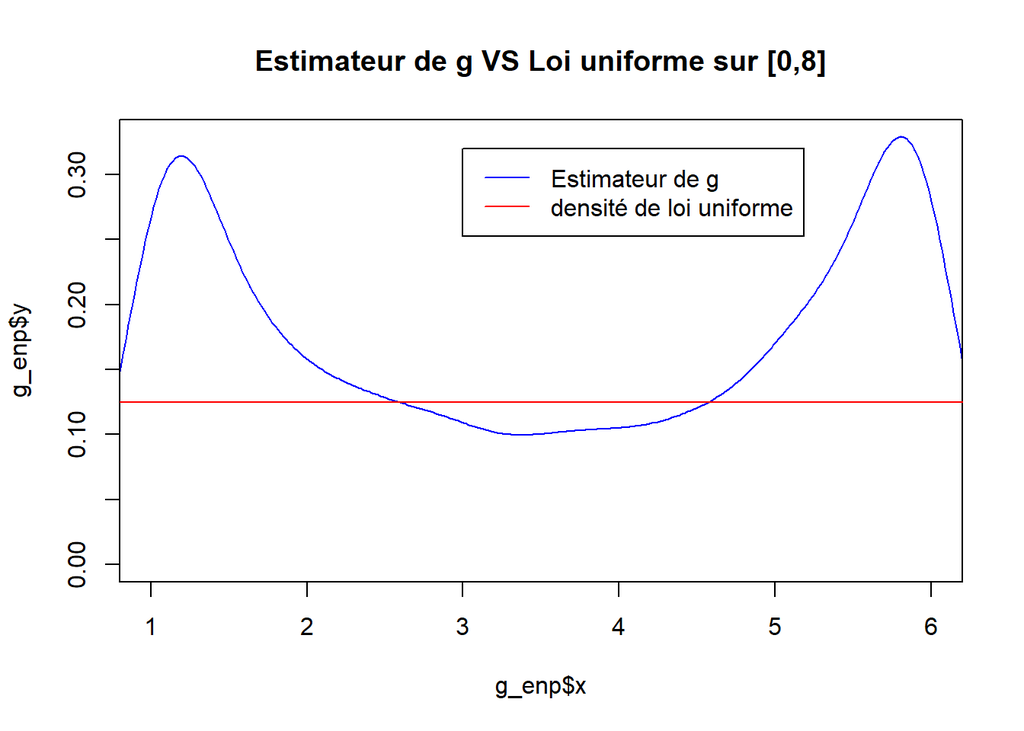

```r
g_enp = bkde(data$X, kernel = "normal", canonical = F, bandwidth = hn, truncate = F)
xunif = runif(10000)
plot(g_enp$x, g_enp$y, type = "l", col = "blue", xlim = c(1,6), main = "Estimateur de g VS Loi uniforme sur [0,8]")
lines(g_enp$x, dunif(g_enp$x,0,8), type = "l", col = "red")
legend(3,0.32, legend =c("Estimateur de g","densité de loi uniforme"), col = c("blue", "red"), lty = 1)
```

##Question 3 Nous traçons un QQplot afin de comparer les quantiles liés à la distribution des Xi à ceux liés à un échantillon de 10000 réalisations d’une loi uniforme sur [0,1]. En théorie, si l’hypothèse selon laquelle g serait uniforme était vrai, nous devrions obtenir une droite. Ce qui n’est pas le cas ici. Nous rejetons donc cette hypothèse.

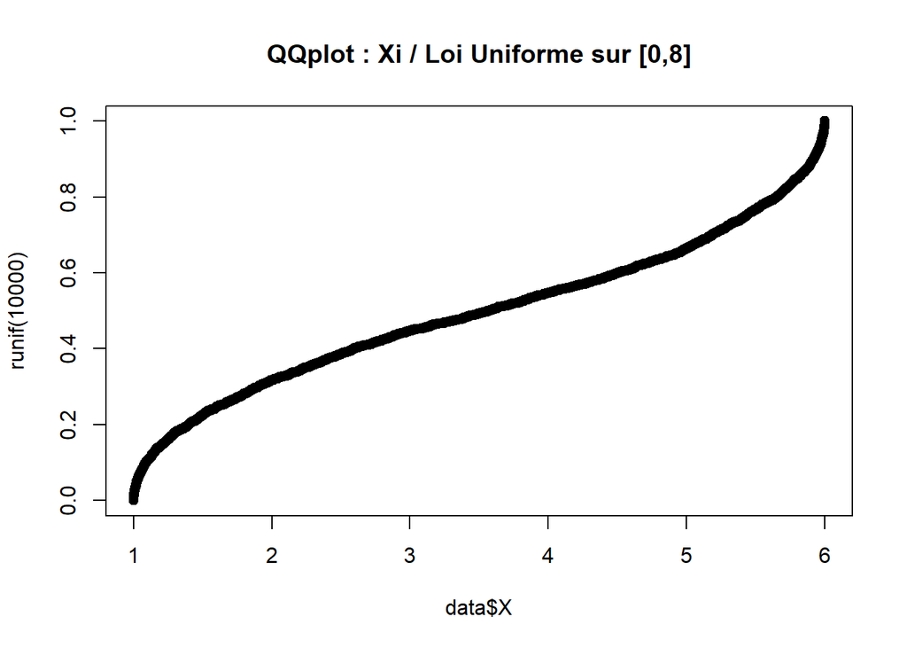

```r
qqplot(data$X, runif(10000), main = "QQplot : Xi / Loi Uniforme sur [0,8]")
```

#Reconstruction de r(x) #Question 1 Le graphique de Y=f(X) tracé au début du rapport montre que la relation entre Y et X n’est probablement pas linéaire. Pour s’en convaincre, nous pouvons étudier les résultats d’une régression linéaire basique. Le premier graphique nous confirme cette impression de non linéarité.

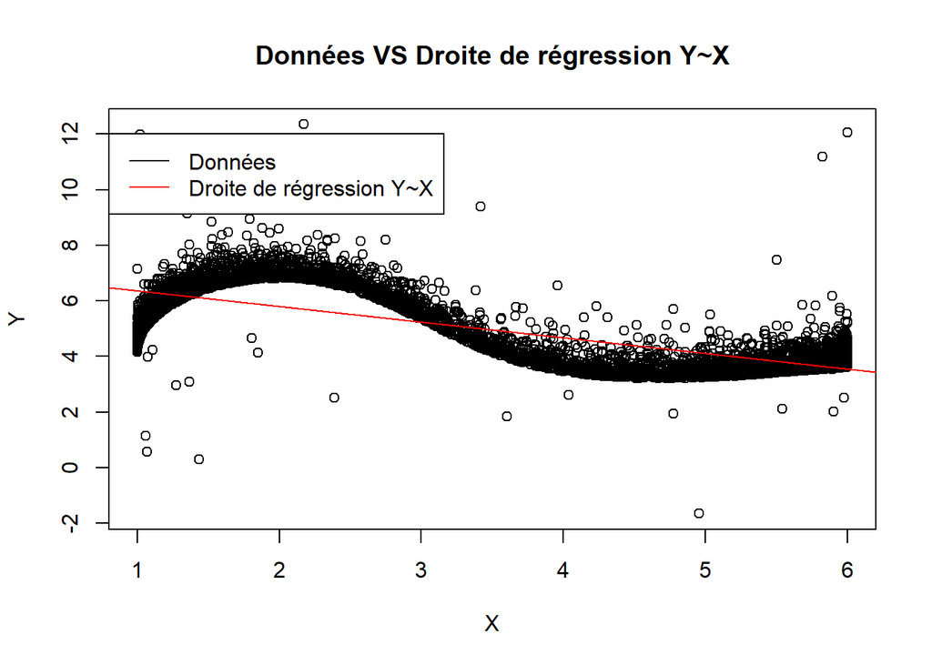

```r
reg = lm(Y~X, data = data)
plot(data$X, data$Y, xlab = "X", ylab = "Y", main = "Données VS Droite de régression Y~X")
abline(reg, col = "red")
legend(0.8,12, legend =c("Données","Droite de régression Y~X"), col = c("black", "red"), lty = 1)
```

Les graphiques de diagnostic du modèle de régression nous montrent que : - une relation non linéaire entre Y et X n’a pas été bien expliquée par le modèle de régression linéaire (parabole observée dans le graphique “Residuals VS Fitted”), - l’hypothèse d’homoscédasticité n’est pas totalement vérifiée (la répartition des résidus est différente sur [3.5,6.3] dans le graphique “Scale-Location”).

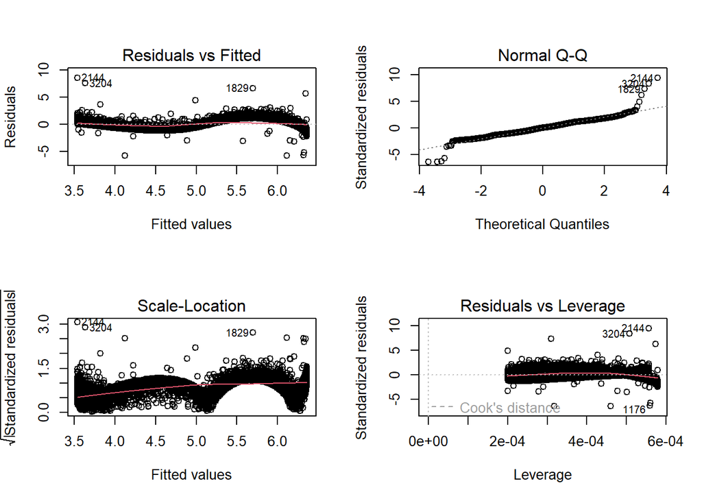

```r
par(mfrow=c(2,2))
plot(reg)
```

Estimer r(x) de manière non paramétrique revient à approcher cette fonction localement, c’est-à-dire autour de chaque x0 en accordant un certain poids aux points voisins. Cette estimation serait donc une première étape nécessaire pour implémenter un modèle linéaire par morceau.